# Weight Exsercise Prediction

#### Plot with points overlayed

This plot shows the number of data-points in each category of user-name, it can be inferred that each person is well represented in the dataset

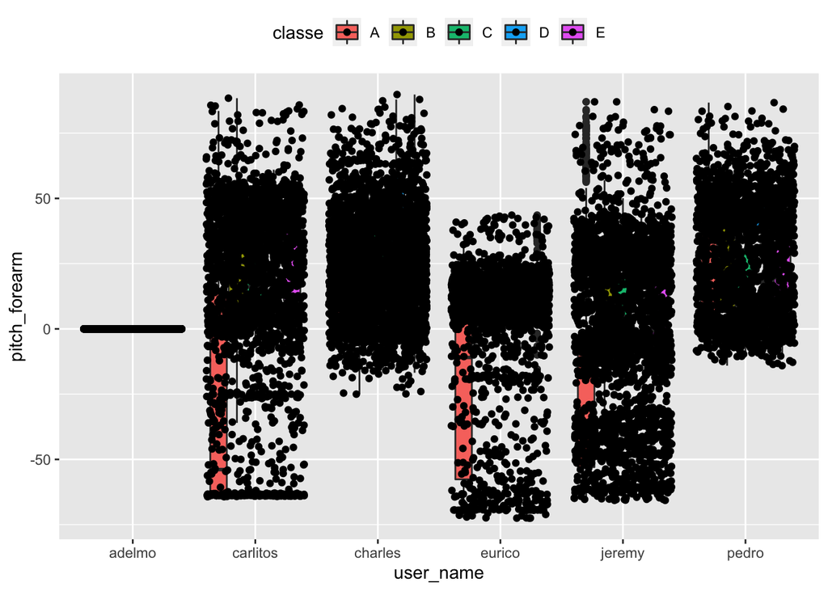

#### Check for correlation between predictors

This plot is not very informational as we have several variable but we can infer that some variables are strongly correlated with others

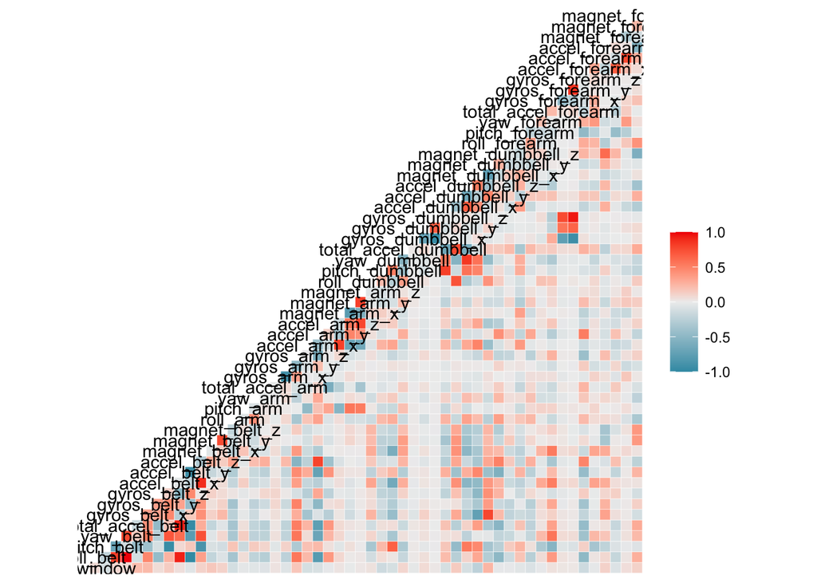

Now is a better tim to eliminate highly correlated columns

```r
high_cor = findCorrelation(cor(df), cutoff = 0.8)

exclude_cols = c(response, high_cor)
```

## Pre-processing for training

To reduce overfitting and also dimentionality, we will use PCA with a thresh of `0.9`

```r
## USe pca to reduce highly correlated variables
pca.all <- preProcess(train_data[, -response], method = 'pca', thresh = 0.9)
train_data.pca.all <- predict(pca.all, train_data[, -response])
validation_data.pca.all <- predict(pca.all, validation_data[, -response])
test_set.pca.all <- predict(pca.all, test_set[, -response])

## remove highly correlated columns and fit pca
pca.excluded <- preProcess(train_data[, -exclude_cols], method = 'pca', thresh = 0.9)
train_data.pca.excluded <- predict(pca.excluded, train_data[, -exclude_cols])
validation_data.pca.excluded <- predict(pca.excluded, validation_data[, -exclude_cols])
#test_set.pca.excluded <- predict(pca.excluded, test_set[, -exclude_cols])
```

## Model

```r
rf.all <- randomForest::randomForest(x = train_data[, -response], y = train_data$classe,
                                 ntree = 100,
                                  ytest =validation_data$classe, xtest = validation_data[, -response])

rf.excluded <- randomForest::randomForest(x = train_data[, -exclude_cols], y = train_data$classe,
                                 ntree = 100,
                                  ytest =validation_data$classe, xtest = validation_data[, -exclude_cols])

rf.pca <- randomForest::randomForest(x = train_data.pca.all, y = train_data$classe,
                                 ntree = 200,
                                 xtest =validation_data.pca.all, ytest =validation_data$classe )

rf.pca.excluded <- randomForest::randomForest(x = train_data.pca.excluded, y = train_data$classe,
                                 ntree = 200,  ytest =validation_data$classe ,
                                 xtest = validation_data.pca.excluded)
```

## Metrics

#### Train Accuracy

```r
rf1 = round(1 - sum(rf.all$confusion[, "class.error"]), 3)
rf2 = round(1 - sum(rf.excluded$confusion[, "class.error"]), 3)
rf3 = round(1 - sum(rf.pca$confusion[, "class.error"]), 3)
rf4 = round(1 - sum(rf.pca.excluded$confusion[, "class.error"]), 3)


print(paste("All Predictors acc:", rf1, "Predictors with no high cor acc: ", rf2,
            "PCA acc: ", rf3, "PCA with high corr removed acc:", rf4 ))
```

```
## [1] "All Predictors acc: 1 Predictors with no high cor acc:  1 PCA acc:  1 PCA with high corr removed acc: 1"
```

#### Validation Accuracy

```r
cm.1 <- round(1 - sum(rf.all$test$confusion[, "class.error"]), 3)
cm.2 <- round(1 - sum(rf.excluded$test$confusion[, "class.error"]), 3)
cm.3 = round(1 - sum(rf.pca$test$confusion[, "class.error"]), 3)
cm.4 = round(1 - sum(rf.pca.excluded$test$confusion[, "class.error"]), 3)

#round(confusionMatrix(validation_data$classe, pred.rf.pca.excluded)$overall[1] , 3)


print(paste("All Predictors acc:", cm.1, "Predictors with no high cor acc: ", cm.2,
            "PCA acc: ", cm.3, "PCA with high corr removed acc:", cm.4 ))
```

```
## [1] "All Predictors acc: 1 Predictors with no high cor acc:  0.999 PCA acc:  1 PCA with high corr removed acc: 1"
```